# Currency Total Return Indices

The P&L of an FX Trade comes from movements in the exchange rate of the pair you are trading and the interest differential between the currencies in that pair.

In this notebook we create “total return indexes” which represents the total return you would receive if any interest received or paid is compounded at every periodic observation.

Charts are displayed which show the cumulative total return for a number of currencies, quoted in USD. We also show the cumulative returns from the spot movements and interest.

## Important - Set DATA_FOLDER to your FXBootcamp resilio location

```r
DATA_FOLDER <- '/Users/damian.fanaro/ResilioSync/FXBootcamp'
```

# Setup

Load the RW data utilities.

```r
source(paste0(DATA_FOLDER,'/Code/tools/r-tools/data-utils.R'))
```

Set AssetList to pull all USD denominated pairs, and set up the environment to point at our boot camp data folder.

```r
ASSET_LIST <- 'AssetsDWX-FX-USD'
```

# Pull and convert data

We convert all our pairs to the USD quote currency to make comparisions easier.

```r
asset_list <- get_asset_list(ASSET_LIST)
prices_df <- get_daily_OHLC(asset_list$Name)
usd_prices_df <- convert_common_quote_currency(prices_df, quote_currency = 'USD')
```

# Get policy interest rates for each currency

```r
currencies <- get_unique_currencies(usd_prices_df)
policy_rates_df <- get_policy_rates(currencies)
```

Now we call the append_interest_rate_differential() function, which does the following:

It constructs total return indexes by Ticker which assume all p&l from interest is compounded into the position on every price observation

- Spot_Return_Indexes is the cumulative product of 1 + Spot_Returns
- Interest_Return_Indexes is the cumulative product of 1 + Interest_Returns
- Total_Return_Indexes is the cumulative product of 1 + Spot_Returns + Interest_Returns

You can use these total return indexes like price series in your analysis.

```r
usd_extended_prices_df <- append_interest_rate_differential(usd_prices_df, policy_rates_df)
head(usd_extended_prices_df)
```

| Ticker | Date | Open | High | Low | Close | Volume | Base | Quote | Base_Rate | Quote_Rate | Rate_Diff | Daycount_Fraction | Interest_Returns | Interest_Accrual_on_Spot | Spot_Returns | Spot_Return_Index | Interest_Return_Index | Total_Return_Index |
| --- | --- | --- | --- | --- | --- | --- | --- | --- | --- | --- | --- | --- | --- | --- | --- | --- | --- | --- |
| AUDUSD | 1999-01-04 | 0.6135 | 0.6226 | 0.6135 | 0.6220 | 0 | AUD | USD | 0.0475 | 0.0475 | 0 | 0.008219178 | 0 | 0 | 0.0155102041 | 1.015510 | 1 | 1.015510 |
| AUDUSD | 1999-01-05 | 0.6122 | 0.6229 | 0.6115 | 0.6220 | 0 | AUD | USD | 0.0475 | 0.0475 | 0 | 0.002739726 | 0 | 0 | 0.0000000000 | 1.015510 | 1 | 1.015510 |
| AUDUSD | 1999-01-06 | 0.6220 | 0.6255 | 0.6209 | 0.6215 | 0 | AUD | USD | 0.0475 | 0.0475 | 0 | 0.002739726 | 0 | 0 | -0.0008038585 | 1.014694 | 1 | 1.014694 |
| AUDUSD | 1999-01-07 | 0.6215 | 0.6305 | 0.6192 | 0.6287 | 0 | AUD | USD | 0.0475 | 0.0475 | 0 | 0.002739726 | 0 | 0 | 0.0115848753 | 1.026449 | 1 | 1.026449 |
| AUDUSD | 1999-01-08 | 0.6287 | 0.6384 | 0.6275 | 0.6346 | 0 | AUD | USD | 0.0475 | 0.0475 | 0 | 0.002739726 | 0 | 0 | 0.0093844441 | 1.036082 | 1 | 1.036082 |
| AUDUSD | 1999-01-11 | 0.6340 | 0.6417 | 0.6320 | 0.6390 | 0 | AUD | USD | 0.0475 | 0.0475 | 0 | 0.008219178 | 0 | 0 | 0.0069335014 | 1.043265 | 1 | 1.043265 |

# Total Return Charts (USD-quote pair convention)

These charts show:

- the total cumulative return from being long these pairs, assuming periodic (nearly daily) compounding of all interest paid or receive (blue)
- the cumulative return from spot exchange rate movements (green)
- the cumulative return from interest paid or received.

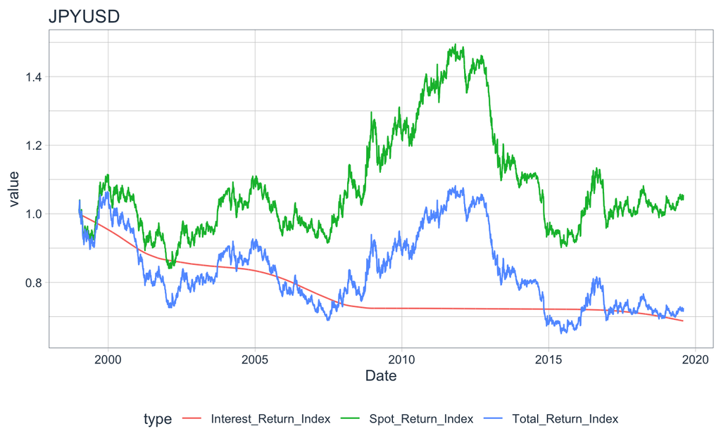

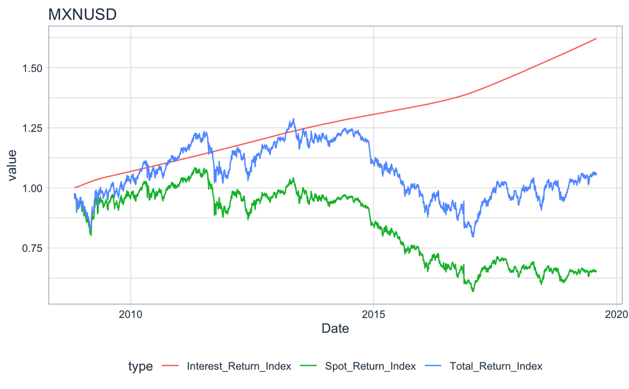

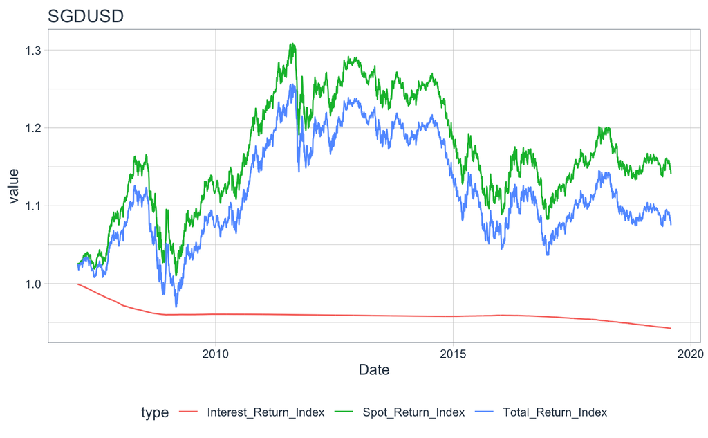

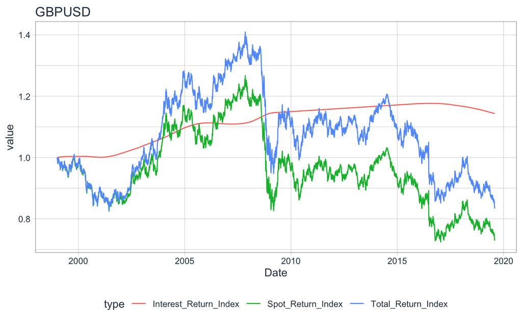

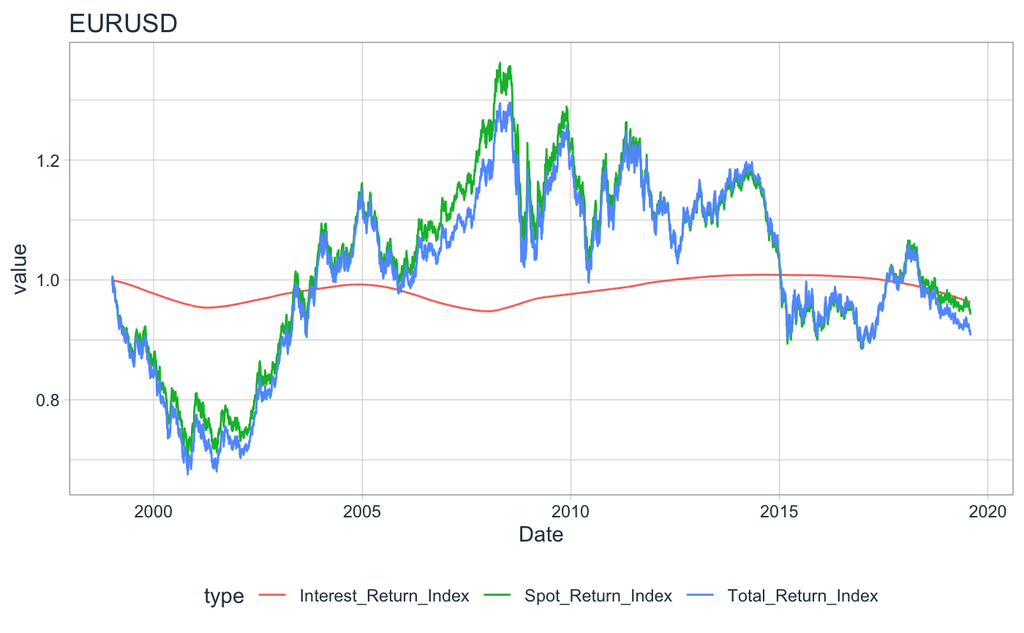

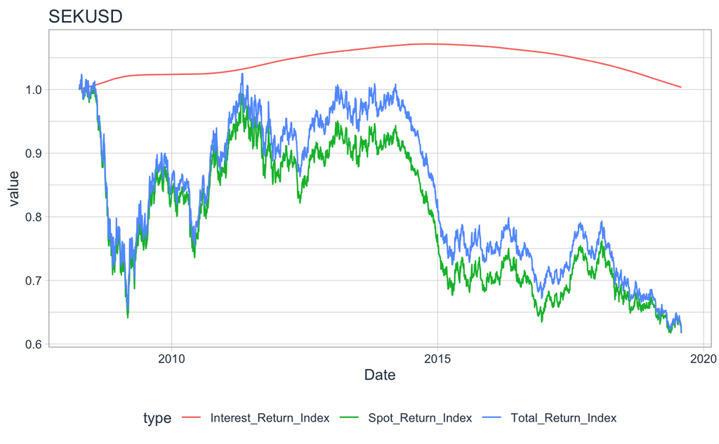

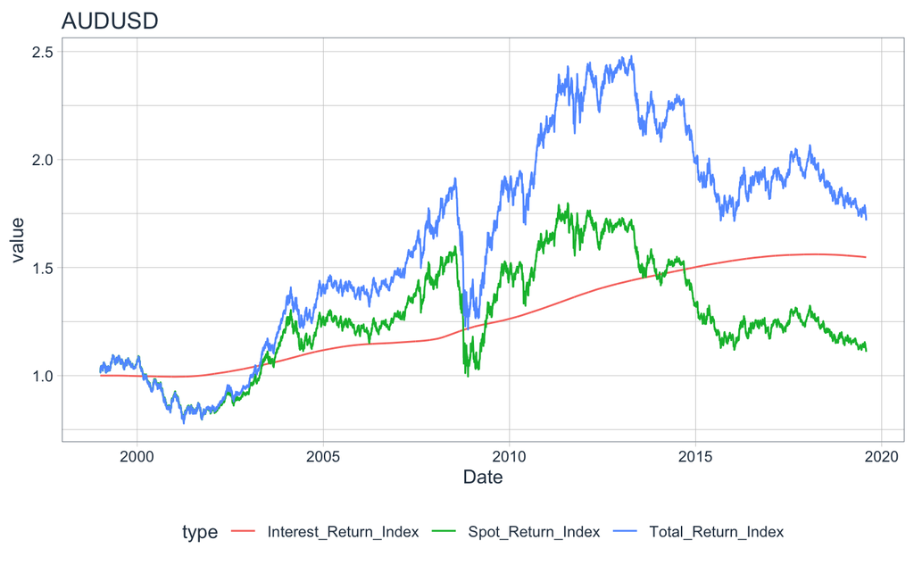

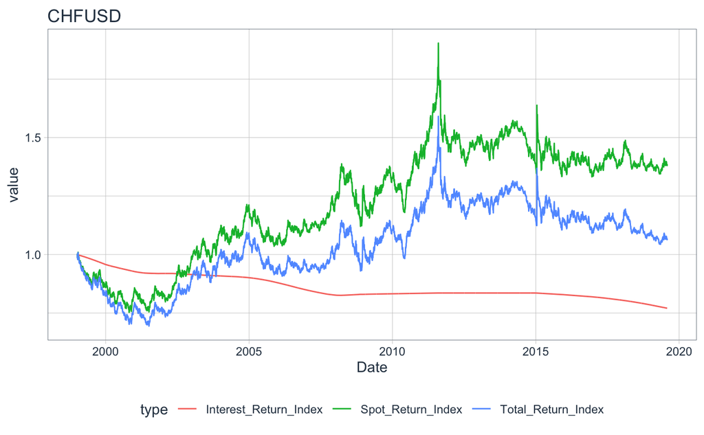

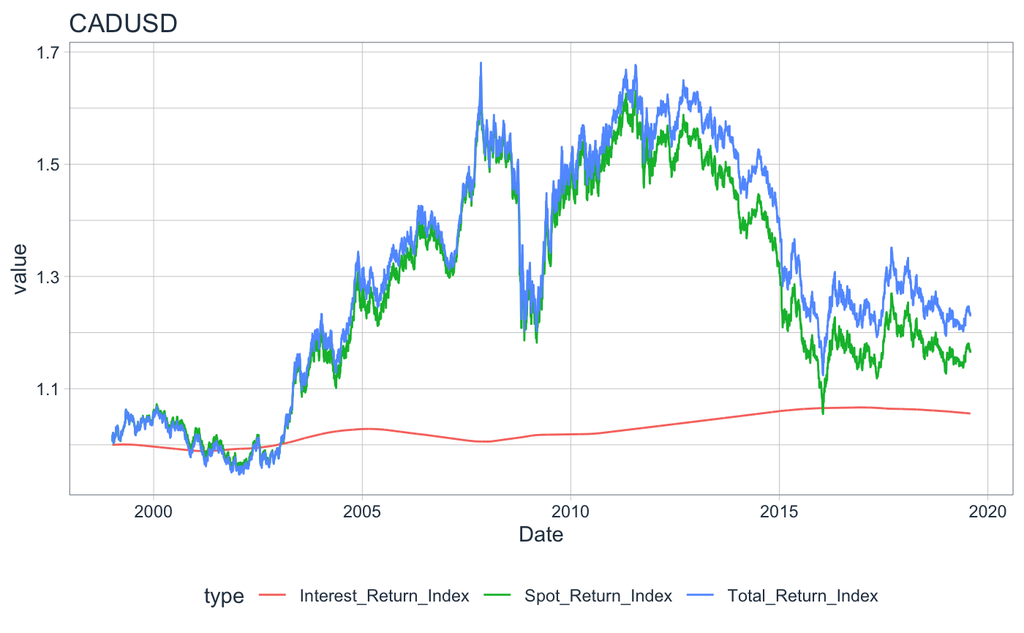

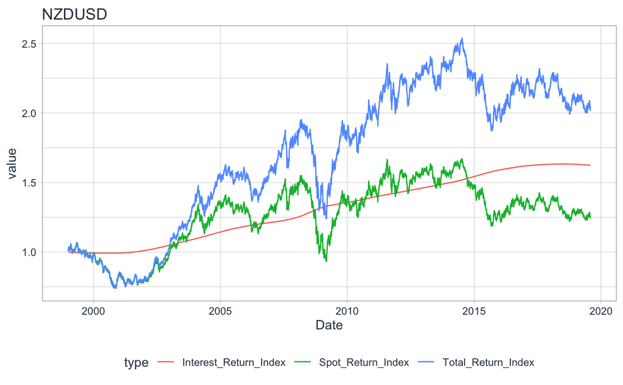

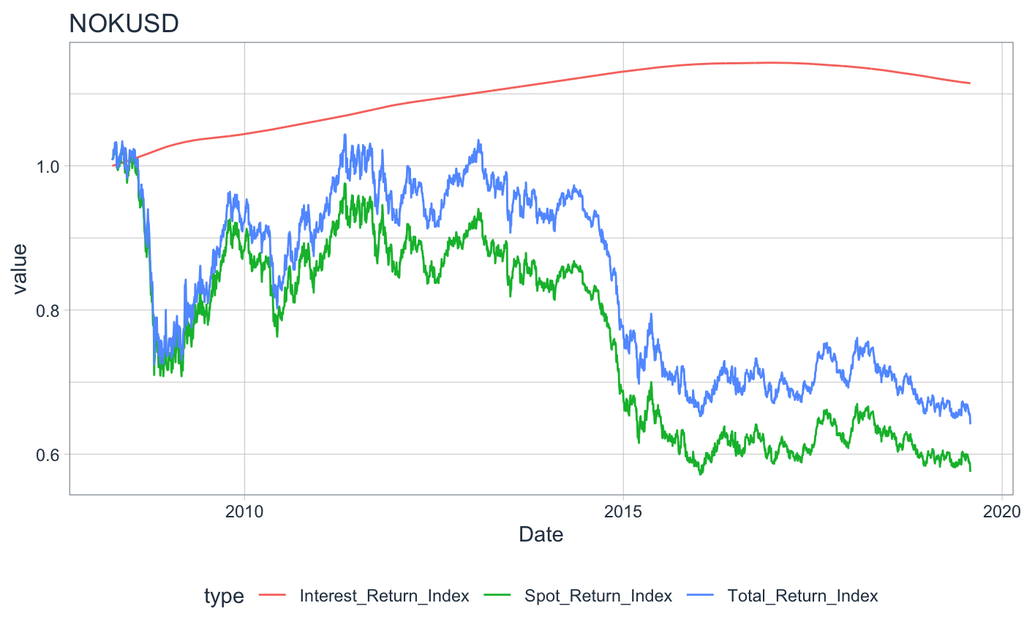

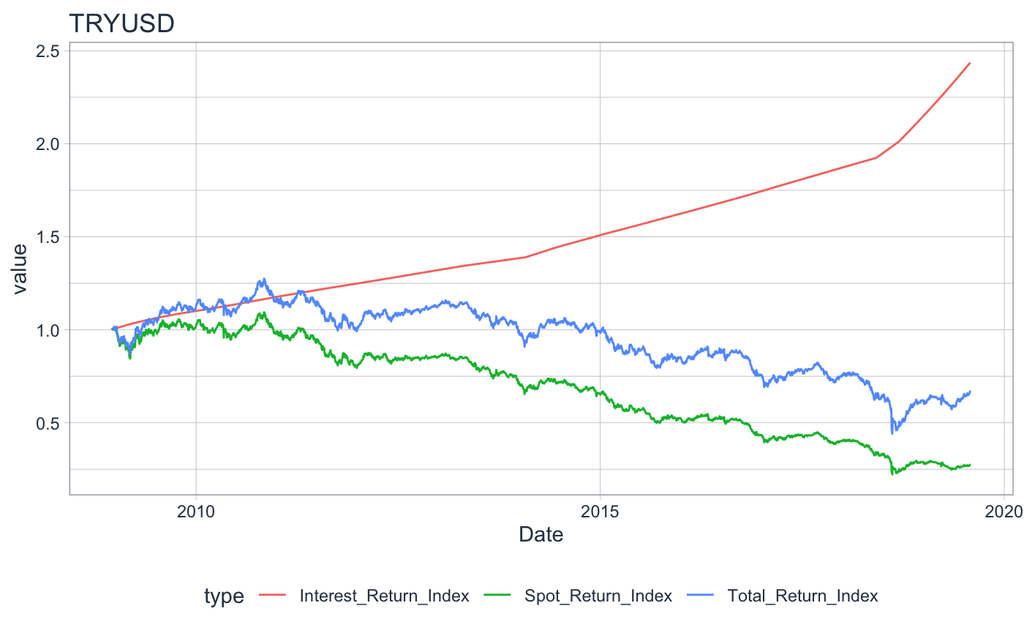

```r
tickers <- distinct(usd_extended_prices_df, Ticker)[[1]]
for (i in tickers) {
  print(usd_extended_prices_df %>%
      filter(Ticker == i) %>%
      select(Ticker, Date, Spot_Return_Index, Interest_Return_Index, Total_Return_Index) %>%
      gather('Spot_Return_Index','Interest_Return_Index','Total_Return_Index', key = 'type', value = 'value') %>%
      ggplot(aes(x = Date, y = value, colour = type)) +
      geom_line() +
      labs(title = i) +
      theme_tq())
}
```